# Trees

This note will dive into two methods which make use of *binary trees* to build models for estimating future data. "The key [difference between classification and regression trees](https://www.differencebetween.com/difference-between-classification-and-vs-regression/) is that in classification the dependent variables are categorical and unordered while in regression the dependent variables are continuous or ordered whole values."

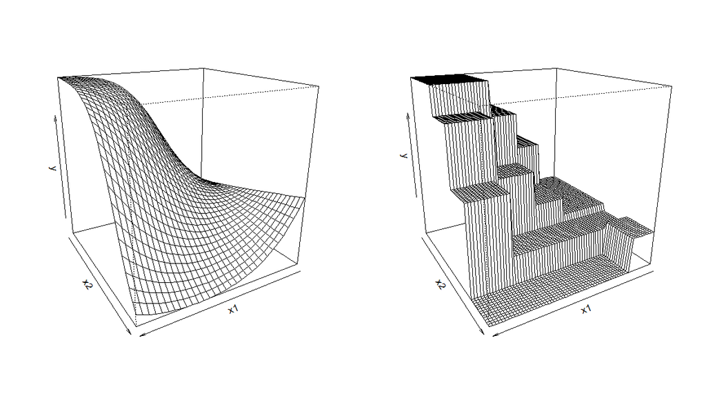

*Continuous 3 dimensional function (left) with a step-wise estimation (right)*

### Advantages of trees

- simplicity and ease of communicating
- compact representation
- speed of computation (easy to parallelize)
- easy to handle both continuous and categorical variables (and mixtures of them)
- easily implement different loss functions
- easy to handle missing data
- automatic variable selection

### Disadvantages of trees

- instability of the results
  - bagging
  - boosting
  - random forest
- difficulties with dynamic data (diff. integrating new information)
- hard to approximate steep functions
- no formal statistical procedures
  - hypothesis testing
  - confidence intervals
  - ...
- difficult to evaluate variable importance

# Regression

Regression trees are *piecewise constant functions* made up of **local averages**. The idea is to split the data into intervals along the $x$-axis, grouping data with as little variation along the $y$-axis as possible. The average of these areas can then give an approximation for data points that fall into this interval.

The concept can be expanded to higher dimensions, as seen in the figure above. We'll start, however, by looking at a 2-dimensional example, along an $x$- and $y$-axis.

However, before we split up the data, we need to ask ourselves three questions.

1. How many intervals do we need to split our $x$-axis into?
2. Where exactly should these splits occur?
3. Which value of $y$ must be assigned to each interval?

The answer to the last question is found with basic calculus. For an interval $R_n$ with length $|R_n|$, $f(x)$ can be estimated from:

$$\frac{1}{|R_n|}\int_{R_n} f(x) dx$$

This can also be thought of as adding the $f(x)$ values across the whole interval, then dividing by the length of the interval. In other words, we're looking for the average of our data over a specific interval defined as $[a,b]$:

$$\hat y = \frac{1}{(b-a)}\sum_a^b y_i$$

The answer to the second question lies in the "slope" of the function we're trying to predict. Large jumps in $y$-values as $x$ increases will lead to large residual errors. This means that areas with high variation in $y$-values should be given smaller intervals along the $x$-axis, and areas with low variation in $y$-values should be given larger intervals along the $x$-axis.

The number of intervals we want to include in our model will depend on how complex of a model we would like to build. Usually, intervals shouldn't be given fewer than 20 data points, although when using very small data sets with high variance exceptions can be made.

By following the same logic as binary trees, regression trees can be represented by directed flow charts.

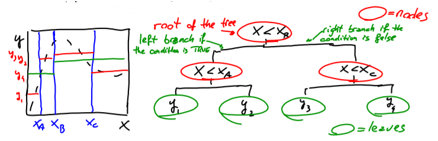

Notice how the possible answers for each node gives a different area on the plot.

These flow charts may not be as visually appealing as the plot of the step-wise estimation shown at the beginning of this section, but they are very cheap to store and compute, since they only really consist of nodes and leaves. It can also be improved very easily by just adding another node.

### Growing a tree

A mentioned above, the more nodes we give our regression trees, the more complex our model will be. The process growing a regression tree is done recursively, by comparing the residual errors a tree with $n$ nodes with the residual error from a tree with $n-1$ nodes.

We start out by giving the tree one node $p=1$. Choosing this node will be describe a little later. The residual errors for each side of the node are found in three steps:

1. Find the average of the data points in that interval.
2. Find and square the residual differences *(i.e. subtract the actual data point from the average and square result)*
3. Add these squared differences together.

Adding the errors from both sides of the interval gives total residual error for this split.

The two new intervals can now also be split, comparing their respective residual errors to a new one generated from the new split. As long as the errors keep decreasing, you can continue splitting and comparing, until each leaf contains only one data point (complete interpolation). This can be avoided by pruning.

It could be useful to note that this method may not be the best at finding global minimums, it is a simple (low complexity), yet acceptable tool for local analysis of some covariates.

### Pruning a tree

By solely minimizing the residual error, as done above, we will eventually begin over-fitting our data. To counter this, we add a *penalty term,* $\alpha J$ to the model which penalizes complexity. That way, at some point, the large number of nodes will cause more error than the better fit is making up for, thus tipping the model from under-fit over to over-fit. Mathematically, this is written as:

$$ C_{\alpha}(J) = \sum _{n=1}^J D_n + \alpha J $$

where $D_n$ is the $n$-th of $J$ residual errors explained above, and $\alpha$ is our tuning parameter.

As $J\rightarrow \infty$, i.e. a lot of nodes are added to the tree, $C(J) \rightarrow \infty$ while $\sum_{n=1}^J D_n \rightarrow 0$, assuming $\alpha > 0$.

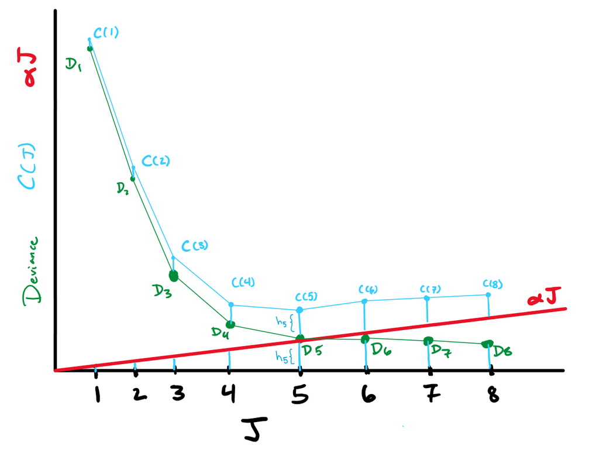

We can use cross-validation to find an acceptable $\alpha$. This process:

1. Splits the data into $k$-folds.
2. Builds $J$ different regression trees, with $1$ to $J$ nodes, respectively, using the data from folds $1,2,...,k-1$
3. Finds each tree's residual error by comparing the model to the $k$-th fold of data.
4. Stores the amount of nodes giving the lowest deviance. Remember that the over-fit model will not give good results on the completely new data from the $k$-th fold.
5. Steps 2,3, & 4 are repeated $k-1$ more times, each time changing only which fold of data to exclude from training and use for testing.
6. The average number folds, along with the average lowest deviance are used to calculate $\alpha$ as the slope between this point and the origin (**red line** in figure over).

Once we have $\alpha$, we will know how complex our model needs to be in order to tell us as much as possible, while retaining reliability. In other words, we know know how many nodes we should include in our regression tree.

### Regression Trees in R

Let's walk through an example of regression tree analysis using R. We will be using an example dataset from http://azzalini.stat.unipd.it/Book-DM/yesterday.dat.

We start by reading in the data. The response values of our data set are split into two parts: yesterday's data and tomorrow's data. This division will come in handy when comparing our models built on yesterday's data with new data from tomorrow.

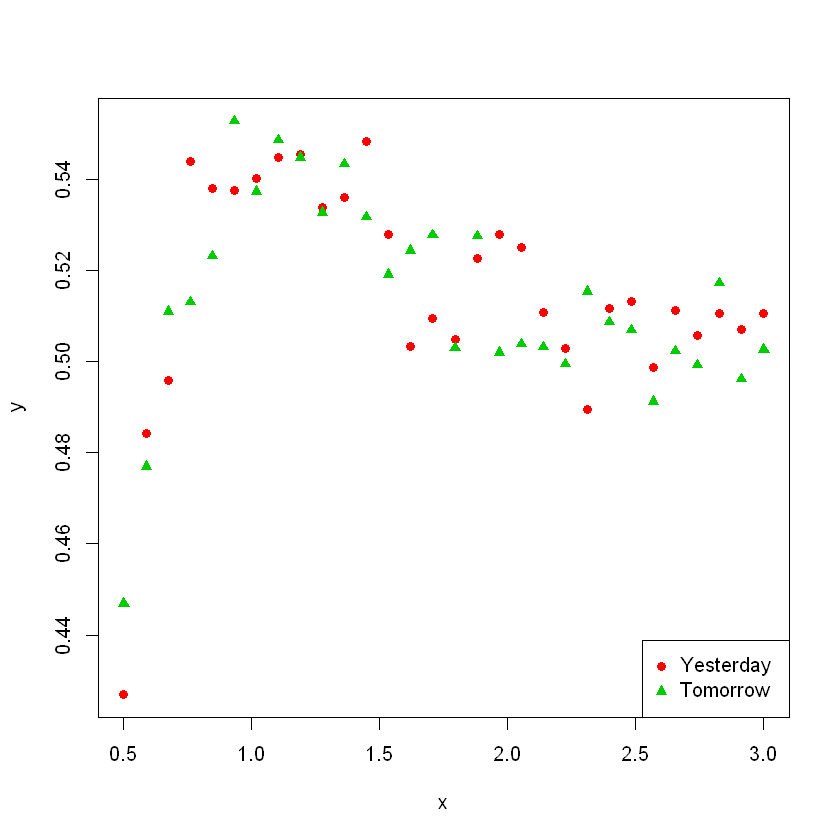

```r
dataset <- read.table("http://azzalini.stat.unipd.it/Book-DM/yesterday.dat", header = TRUE)
x <- rep(dataset$x,2)
y <- c(dataset$y.yesterday, dataset$y.tomorrow)


# figure 4.19
plot(x, y, type = "n")
points(dataset$x, dataset$y.yesterday, pch = 16, col = 2)
points(dataset$x, dataset$y.tomorrow, pch = 17, col = 3)
legend('bottomright', legend = c("Yesterday", "Tomorrow"), pch = 16:17, col = 2:3)
```

As we can see in the plot, the two data sets seem to follow the same trend, which means we should be able to build a model for them.

The next step is to actually build the tree from yesterday's data. We make use of the R library `tree` to create this estimation.

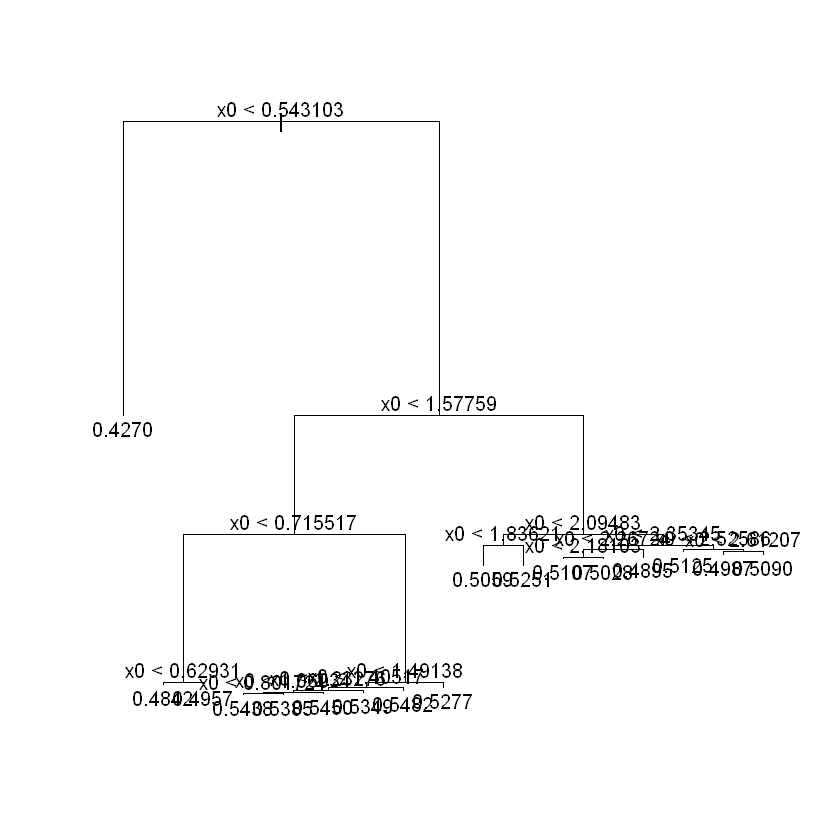

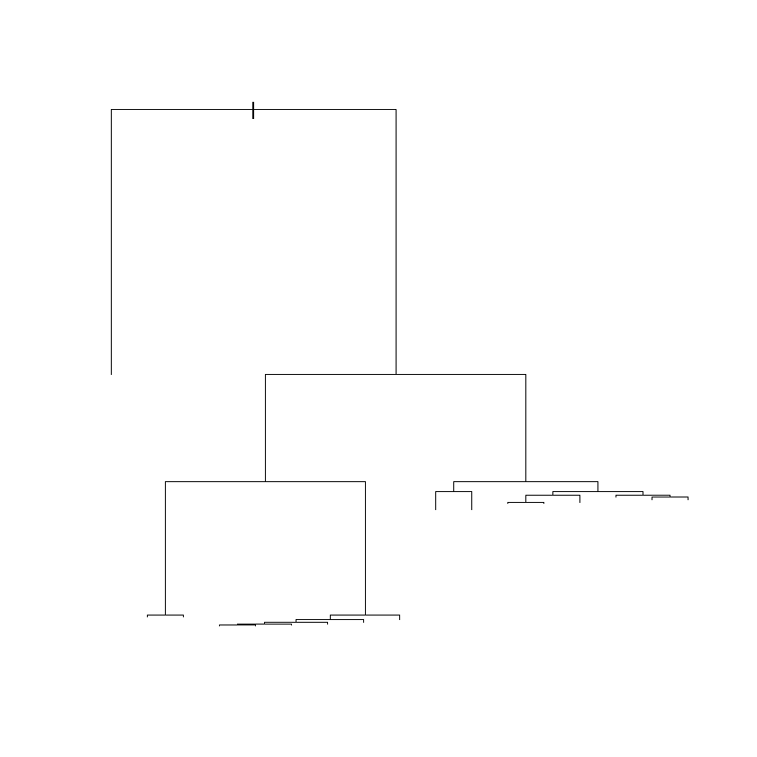

```r
# install.packages('tree')
library('tree')

x0 <- dataset$x
y0 <- dataset$y.yesterday
t3 <- tree(y0 ~ x0, control = tree.control(nobs = 30, mindev = 0.001, minsize = 2))
# figure 4.21a
plot(t3)
text(t3)
plot(t3)
```

Let's now try *pruning* our tree using data from tomorrow to see which nodes should be kept, and which be can neglected. This can be done using `prune.tree` from the `tree` library, and setting `newdata` = tomorrow's data. This function executes a cross-validation to find the optimal $\alpha$ for the future data. It then returns a model mapping model complexities with their relative deviance values.

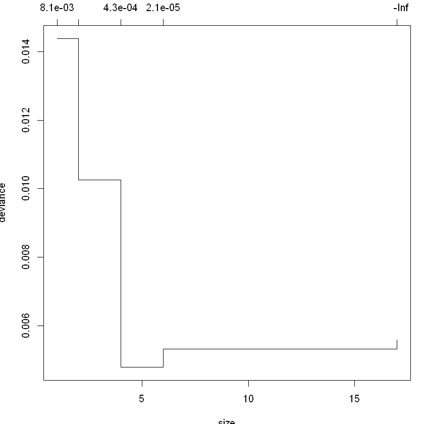

```r
par(mar = c(3.5, 3.5, 2, 1) + 0.1)
p3 <- prune.tree(t3, newdata = data.frame(x0 = x0, y0 = dataset$y.tomorrow))
# figure 4.21b
plot(p3)
```

The decreasing in deviance as size increases from 0 shows our model getting better. Eventually, we see an increase in deviance again. This means that we've reached the balance point between complexity and deviance.

Since we first achieved the lowest recorded deviance at size 4, we can tell the `prune.tree` function to use this as the "best" parameter. Now, it will split the data into 4 intervals, then explain what percentage of the data points fall within these intervals

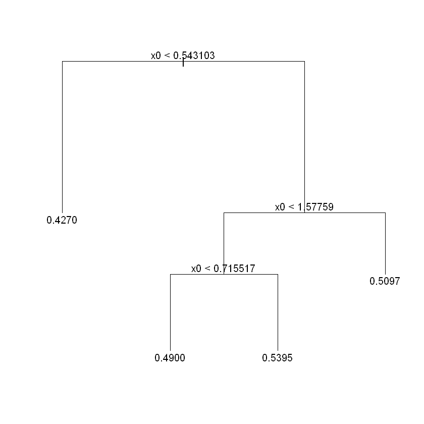

```r
p4 <- prune.tree(t3, best = 4)
# figure 4.21c
plot(p4)
text(p4)
```

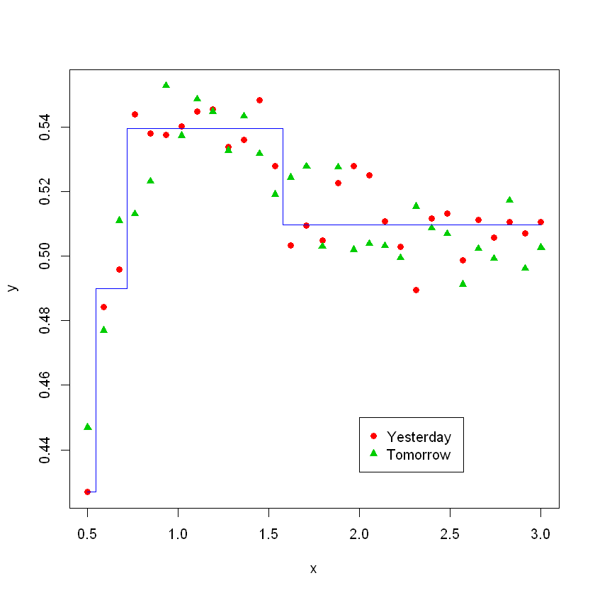

```r
# figure 4.21d
x0 <- seq(0.5, 3, length = 5000)
plot(x, y, type = "n")
points(dataset$x, dataset$y.yesterday, pch = 16, col = 2)
points(dataset$x, dataset$y.tomorrow, pch = 17, col = 3)
legend(2, 0.45, legend = c("Yesterday", "Tomorrow"), pch = 16:17, col = 2:3)
lines(x0, predict(p4, newdata = data.frame(x = x0)), col = 4)
```

Our model seems to fit our data well, while remaining incredibly simple.

# Classification

Classification trees are a lot like regression trees, only, they help compare *qualitative* data, whereas regression trees work on quantitative data.

With regression trees, we broke our data sets into intervals based on a series of booleans about the numeric values of the response variable. The result was a binary tree, with local averages at the leaf nodes, depicting that region's particular step function.

Classification tress follow a similar structure, but get the values of the leaf nodes in a different manner. Whereas the values at the leaf nodes of regression trees come directly from the response values in their respective intervals, the leaf nodes of classification trees represent one of the states within the given discrete state-space, $K$, making up the response domain. This is just fancy talk for saying that the categories making up our response variable are found at the leaf nodes of a classification tree. An approximation of how sure you can be that data points within that interval belong to this category is also generated for leaf node.

This means that we are no longer interested in finding the data's probability distribution, $f(x)$, since with qualitative data such a distribution doesn't make sense. We are rather interested in finding the *long term probabilities,* $\pi_k$. This will tell us the probability of a new data point having response value $y=k$, no matter what interval it falls into.

### Long term probabilities

The optimal classification tree breaks up all future data sets into $J$ partitions, or *regions,* where each partition has the highest probability of correctly guessing the response values for the data. In order to do so, we need to find the long term probability that a response variable will be in a specific state.

Let's start simple, by using a binary response variable, with possible values 0 and 1. We can then define $\pi_1$ as the long term probability of getting a response variable equal to 1:

$$\pi_1(x)=P(Y=1 | X=x) $$

The exact real values of $\pi_k$ are hard to find, because you would need an $\infty$ number observations to test. We can instead find an estimate of $\pi_k$ from our data, by finding the ratio of observations in state $k=1$ for each of our partitions, denoted as $p_j$ below:

$$ \pi_{1} (x) = \sum_{j=1}^{J} p_j I(x \in R_j) $$

The $I(x \in R_j)$ depicts our frequency function, or how many observations this probabilities represents. The range $[1, J]$ just checks all of our $J$ partitions we've split our data into. As we can see, $\pi_{1}$ is the sum of all of these local probabilities $p_j$ weighted by their frequency.

The local probability $p_j$ can be approximated from our data set by finding how many observations in this interval actually have response values equal to $1$. Again, the $I(y=1)$ refers to the frequency of observations which help us to count each of the variables in this category $y=1$.

$$\hat p_j= \frac{1}{n_j} \sum_{i\in R_j} I(y_i=1)$$

So far we've found the long term probabilities of our different states, $\pi_k$, along with the local probabilities of new observations having response variable $y_{new}=1$, $p_j$. We can make this slightly more general by saying $p_{j,k}$ is the probability of data in region $R_j$ having response variable $y=k$.

We're soon ready to compare our model to model's developed with other methods, we're just missing our comparison metric.